# Funciones Polinomicas

Tiene la forma de $$P(x)=a_{n}x^{n} + a_{n-1}x^{n-1}+...+a_{2}x^{2}+a_{1}x + a_{1}$$

a una función que tiene esta forma se le llama polinomio de grado $n$. A los elementos $a$ los llamaremos coeficientes donde $a \in R$.

**Por ejemplo:**

$$P(x)= 2x^{7} - x^{4} + 3x^{2} + 4$$

que es un polinomio de grado 7.

## Librerias

```python
import matplotlib.pyplot as plt
import numpy as np

#Configurando Latex
# Configuración de Matplotlib para usar LaTeX
plt.rcParams.update({
    "text.usetex": True,
    "font.family": "serif",
    "font.serif": ["Computer Modern Roman"],
    "text.latex.preamble": r"\usepackage{amsmath}"
})
```

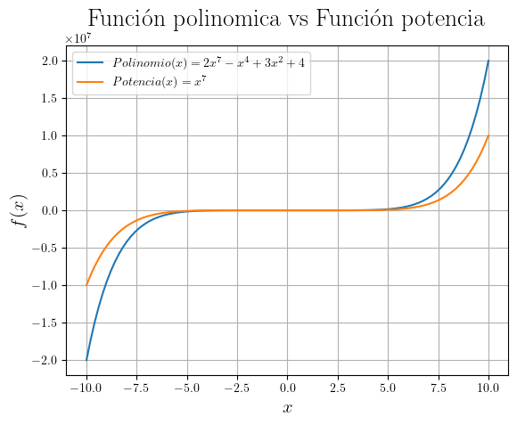

```python
#Funcion polinomica
def Polin(x):
  pol = (2*(x**7)-(x**4)+3*(x**2)+4)
  return pol

#Funcion potencia
def Pot(x):
  return x**7

N=100
x = np.linspace(-10,10, num=N)
y1 = Polin(x)
y2 = Pot(x)

fig, ax = plt.subplots()
ax.plot(x,y1,label=r'$Polinomio(x) = 2x^7-x^4+3x^2+4$')
ax.plot(x,y2,label=r'$Potencia(x) = x^7$')
plt.title(r'Función polinomica vs Función potencia',fontsize=20)
plt.xlabel(r'$x$',fontsize=15)
plt.ylabel(r'$f(x)$',fontsize=15)
plt.legend()
plt.grid()
plt.show()
```

Como se puede observar las funciones $Polinomio$ y $Potencia$, tienen comportamientos similar. Pero cuando las graficamos juntas, podemos ver que sus valores no son los mismos.

### ¿Qué comportamiento tendrá la gráfica dependiendo del exponente?

Digamos que si nuestro mayor exponen es `par` o `impar`. *¿Cómo se verá la gráfica?*

> Averiguemoslo

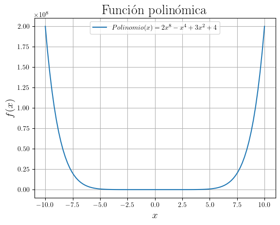

```python
#Funcion polinomica
#Con factor positivo
def Polin(x):
  pol = (2*(x**8)-(x**4)+3*(x**2)+4)
  return pol

N=100
x = np.linspace(-10,10, num=N)
y1 = Polin(x)


fig, ax = plt.subplots()
ax.plot(x,y1,label=r'$Polinomio(x) = 2x^8-x^4+3x^2+4$')
plt.title(r'Función polinómica',fontsize=20)
plt.xlabel(r'$x$',fontsize=15)
plt.ylabel(r'$f(x)$',fontsize=15)
plt.legend()
plt.grid()
plt.show()
```

Cómo se puede ver su comportamiento es como una $\bigcup$

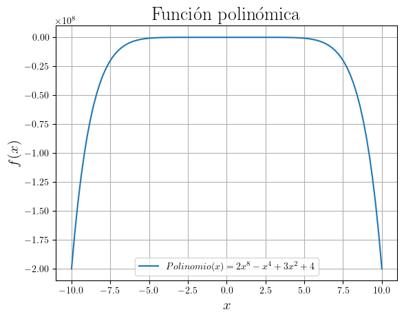

```python
#Funcion polinomica
#Con factor negativo
def Polin(x):
  pol = (-2*(x**8)-(x**4)+3*(x**2)+4)
  return pol

N=100
x = np.linspace(-10,10, num=N)
y1 = Polin(x)


fig, ax = plt.subplots()
ax.plot(x,y1,label=r'$Polinomio(x) = 2x^8-x^4+3x^2+4$')
plt.title(r'Función polinómica',fontsize=20)
plt.xlabel(r'$x$',fontsize=15)
plt.ylabel(r'$f(x)$',fontsize=15)
plt.legend()
plt.grid()
plt.show()
```

Cómo se puede ver su comportamiento es como una $\bigcap$

### ¿Afectará en algo?

Si quitamos los terminos restantes, ¿que pasará?

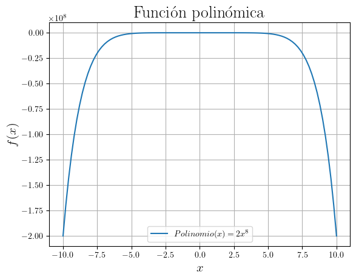

```python
#Funcion polinomica
#Con factor negativo
def Polin(x):
  pol = (-2*(x**8))
  return pol

N=100
x = np.linspace(-10,10, num=N)
y1 = Polin(x)


fig, ax = plt.subplots()
ax.plot(x,y1,label=r'$Polinomio(x) = 2x^8$')
plt.title(r'Función polinómica',fontsize=20)
plt.xlabel(r'$x$',fontsize=15)
plt.ylabel(r'$f(x)$',fontsize=15)
plt.legend()
plt.grid()
plt.show()
```

Cómo se puede observar parece no afectarle, en el caso negativo.

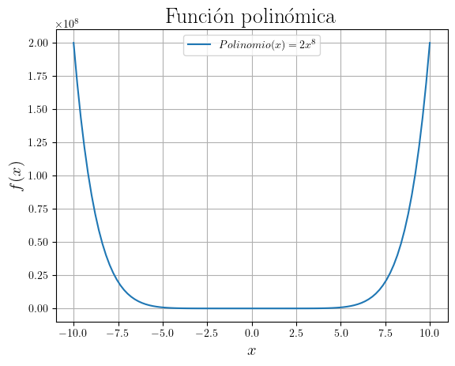

```python
#Funcion polinomica
#Con factor positivo
def Polin(x):
  pol = (2*(x**8))
  return pol

N=100
x = np.linspace(-10,10, num=N)
y1 = Polin(x)


fig, ax = plt.subplots()
ax.plot(x,y1,label=r'$Polinomio(x) = 2x^8$')
plt.title(r'Función polinómica',fontsize=20)
plt.xlabel(r'$x$',fontsize=15)
plt.ylabel(r'$f(x)$',fontsize=15)
plt.legend()
plt.grid()
plt.show()
```

De igual manera para el caso positivo, parece no afectarle.